# 09 Workflows

Agenda:

- Eurostats review
- Workflows
- Discussion for next week

```r
# Look at this nice way to load libraries without filling the screen with junk
suppressMessages(library(tidyverse))
```

## Eurostats and other questions

```r
library(eurostat)
data <- get_eurostat(id="cdh_e_diss", time_format = "num")
```

```
==================================================

Table cdh_e_diss cached at /var/folders/40/g5h19fsj5yl8_tr49ny3jqx0h1wp05/T//RtmpdlsIXZ/eurostat/cdh_e_diss_num_code_TF.rds
```

```r
data <- label_eurostat(data)
```

If RStudio won’t make a nice screen version of the table (happens on Windows computers), use the `View()` function:

```r
data %>% View()
```

Here’s our worked example derived from Marc’s homework:

I think the magic here is `spread`: we need to have the 2006 and 2009 values on the same line so we can calculate whether the trend is increasing or decreasing. The `geom_curve()` function draws a series of lines from (x, y) to (xend, yend); the `curvature=0` argument makes the curve… straight. You can’t do this with `geom_line()`, since geom_line draws one big line joining a vector of (x, y) values together.

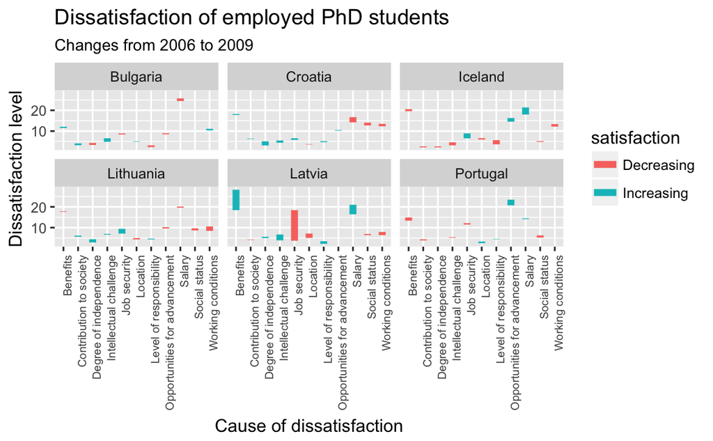

```r
data %>%
  filter(sex == "Total", y_grad=="Total") %>%
  spread(time, values) %>%
  filter(!is.na(`2009`), !is.na(`2006`)) %>%
  mutate(satisfaction=if_else(`2009`>`2006`, "Increasing", "Decreasing")) %>%
  ggplot(aes(x=reason, y=`2006`, xend=reason, yend=`2009`, colour=satisfaction)) +
    geom_curve(curvature=0, size=2) +
    facet_wrap(~ geo) +
    theme(axis.text.x=element_text(angle=90, hjust=1, size=7)) +
    labs(y="Dissatisfaction level", x="Cause of dissatisfaction") +
    ggtitle("Dissatisfaction of employed PhD students",
            subtitle="Changes from 2006 to 2009")
```

### Producing publication quality graphics.

The `ggsave()` function makes a graphics file of the last image generated. Important arguments: - filename, path to specify where to put the file (the type of graphic is determined by the filename suffix, which should usually be `.png` or `.pdf`) - height, width, units (“in”, “mm”, “cm”)

```r
ggsave("MichaelHappyPhD.pdf", width=20, height=10, units="cm")
```

## Recoding category labels (i.e. “levels” of “factors”) and setting the order of the levels

- Adapted from https://debruine.github.io/recode.html

Recode values:

```r
countries <- c("AU", "AT", "SK", "SI")
recode(countries, AU="Australia", AT="Austria", SK="Slovakia", SI="Slovenia")
```

```
[1] "Australia" "Austria"   "Slovakia"  "Slovenia"
```

Turn a string into ordered factors:

```r
countries <- c("Australia", "Austria", "Slovakia", "Slovenia")
factor(countries, levels=c("Slovakia", "Austria", "Slovenia", "Australia"))
```

```
[1] Australia Austria   Slovakia  Slovenia
Levels: Slovakia Austria Slovenia Australia
```

The Tidyverse’s `forcats` package does all this very nicely too

## Workflows

- Techniques for collaboration.
  - Git is state of the art for plain text-based collaboration
  - Suitable for working with code and data (cf. CLDC materials)

  http://rogerdudler.github.io/git-guide/
  - git
  - git via github
    - De facto master copy
    - Website can have an “Issue tracker” and Wiki
    - A brilliant way to coordinate data compilation from lots of people
  - github via RStudio

  Other advantages
  - Gives you versioned backups for free
  - Interacts well with archiving/publishing tools
- Archiving and publishing research analyses online (using e.g. FigShare).
  - Replicability
  - Quality control
  - https://figshare.com/collections/Supplementary_material_from_A_Bayesian_phylogenetic_study_of_the_Dravidian_language_family_/4025020
  - https://figshare.com/articles/Dative_Sickness_A_Phylogenetic_Analysis_of_Argument_Structure_Evolution_in_Germanic_supplementary_materials_/4625941
  - Concerns (privacy, getting scooped, etc.)
- How to report your analysis in a thesis or paper.
  - Best practice in methods description
  - Issues are different for visualisation
- Other workflows (leaving RStudio for the text editor and command line)
  - Notebook versus other kinds of markdown files
  - R scripts
    - Running R scripts through RStudio
    - Writing R scripts with a text editor; running R scripts from the commandline
- Dynamic visualisation
  - Shiny Apps (http://shiny.rstudio.com/gallery/)
  - Colour Vision Simulator
- Final meeting
  - What would you like to discuss?
  - Final assignment: Produce a novel and interesting visualisation of data from your own PhD project. In the absence of suitable data you can use some other data related to your project. Present this in a short, compilable report in Markdown format (a Markdown document designed for printing, not a notebook). **Due date:** To be decided.